# Ghost Flights – pilot

Aine Fairbrother-Browne

03/22

# Introduction

What is your novel idea? Why should we care? How are you going to prove your point?

- Outline environmental problem posed by ghost flights or semi-full flights
- Difficulty of obtaining ghost flight data - as highlighted by the recent Guardian article/ episode of Guardian In Focus with investigative journalism
- Is it possible to detect ghost flights from bulk, summarised CAA data
- This can tell us about airline activities and allow us to scrutinise their practices without having to jump through the loopholes posed by obtaining this kind of (seemingly secret!) data

# Obtain data

- I downloaded 2021 UK airline activity data from [here](https://www.caa.co.uk/data-and-analysis/uk-aviation-market/airlines/uk-airline-data/uk-airline-data-2021/)
- It is divided up by month, and each monthly dataset must be downloaded separately
- For the pilot study, I downloaded the following table: “Table 03 - All Services”, using the command `wget -c https://www.caa.co.uk/Documents/Download/8634/87542ebf-3d02-44c1-8650-d8dbd6eca742/2863 -O dec_21_all_services.csv;`
- The inclusion criteria as per CAA for airlines and passengers contained in their data is as follows:
- Airlines: “Airlines with an aircraft having a Maximum Take Off Mass (MTOM) above 40 tonnes and/or an A type Operating licence or Air Transport Licence are required, under Section 84 (1) of the Civil Aviation Act 1982, to report regular monthly data. However, charter services performed by aircraft below 15 tonnes MTOM and sole use/exempt in type are not included in published tables.”
- Passengers: “Recorded as ‘uplifted passengers’, they cover passengers carried by the airlines worldwide, not only to/from the UK, and relate to passengers who have paid the equivalent of 25% of the normal fare. Note that infants under 2 years are not included.”
- Read in downloaded data

```r
dec21.allservices = readr::read_csv("./data/dec_21_all_services.csv")
```

- A quick preview of the data structure

```r
dec21.allservices %>%
  DT::datatable(.,
                extensions = 'FixedColumns',
                options = list(
                  dom = 't',
                  scrollX = TRUE,
                  scrollCollapse = TRUE
                ))
```

|  | rundate | reporting_period | type_of_operations | airline_name | aircraft_km_x1000 | no_flights | aircraft_hours | total_passengers_uplifted | seat_km_available_x1000 | seat_km_used_x1000 | cargo_tonnes_uplifted | total_tonne_km_available_x1000 | tot_mail_tonne_km_used_x1000 | total_freight_tonne_km_used_x1000 | total_passenger_tonne_km_used_x1000 |
| --- | --- | --- | --- | --- | --- | --- | --- | --- | --- | --- | --- | --- | --- | --- | --- |
| 1 | 2/18/2022 9:59:06 AM | 202112 | Passenger | 2 EXCEL AVIATION LTD T/A THE BLADES BROADSWORD SCIMITAR SABRE AND T2 | 42 | 41 | 72 | 807 | 2153 | 1326 | 0 | 352 | 0 | 0 | 133 |
| 2 | 2/18/2022 9:59:06 AM | 202112 | Passenger | ACROPOLIS AVIATION LTD | 45 | 7 | 58 | 67 | 853 | 426 | 0 | 157 | 0 | 0 | 36 |
| 3 | 2/18/2022 9:59:06 AM | 202112 | Passenger | AER LINGUS (UK) LTD | 667 | 111 | 825 | 13164 | 171371 | 80043 | 8 | 23893 | 0 | 54 | 7515 |
| 4 | 2/18/2022 9:59:06 AM | 202112 | Passenger | AIRTANKER SERVICES LTD | 197 | 33 | 260 | 2556 | 63347 | 17826 | 0 | 8049 | 0 | 0 | 1640 |
| 5 | 2/18/2022 9:59:06 AM | 202112 | Passenger | AURIGNY AIR SERVICES | 167 | 789 | 636 | 27811 | 13063 | 7228 | 8 | 1347 | 0 | 0 | 605 |
| 6 | 2/18/2022 9:59:06 AM | 202112 | Passenger | BA CITYFLYER LTD | 952 | 1537 | 2012 | 75098 | 93328 | 47509 | 0 | 9333 | 0 | 0 | 4240 |
| 7 | 2/18/2022 9:59:06 AM | 202112 | Passenger | BAE SYSTEMS (CORP AIR TVL) LTD | 4 | 12 | 8 | 98 | 182 | 30 | 0 | 17 | 0 | 0 | 3 |
| 8 | 2/18/2022 9:59:06 AM | 202112 | Passenger | BLUE ISLANDS LIMITED | 125 | 648 | 497 | 20741 | 8191 | 4498 | 2 | 737 | 0 | 0 | 404 |
| 9 | 2/18/2022 9:59:06 AM | 202112 | Passenger | BRITISH AIRWAYS PLC | 36087 | 12155 | 50997 | 1535578 | 8860379 | 6158978 | 32458 | 1507502 | 5942 | 219125 | 604177 |
| 10 | 2/18/2022 9:59:06 AM | 202112 | Passenger | CATREUS AOC LTD | 147 | 79 | 209 | 148 | 1574 | 673 | 0 | 465 | 0 | 0 | 67 |

[output cut: 30 more lines]

# Filter data

- We will filter for only passenger services, as this is the focus of the project
- Also filter out airlines that carried 0 passengers - we will come back to these

```r
dec21.allservices = dec21.allservices %>%
  dplyr::filter(type_of_operations=="Passenger") %>%
  dplyr::filter(total_passengers_uplifted>0)
```

# Understanding the data

```r
dec21.allservices %>%
  colnames()
```

```
##  [1] "rundate"                             "reporting_period"
##  [3] "type_of_operations"                  "airline_name"
##  [5] "aircraft_km_x1000"                   "no_flights"
##  [7] "aircraft_hours"                      "total_passengers_uplifted"
##  [9] "seat_km_available_x1000"             "seat_km_used_x1000"
## [11] "cargo_tonnes_uplifted"               "total_tonne_km_available_x1000"
## [13] "tot_mail_tonne_km_used_x1000"        "total_freight_tonne_km_used_x1000"
## [15] "total_passenger_tonne_km_used_x1000"
```

- These bulk data summarise all of the flights run by UK airlines in a given time period
- Let’s take a look at the columns of interest included in this data and understand them
- Sources: [airlinegeeks.com](https://airlinegeeks.com/2015/12/28/airline-metrics-available-seat-kilometers/), [caa.co.uk](https://www.caa.co.uk/data-and-analysis/uk-aviation-market/airlines/notes-and-faqs/), [ir.aeroflot.com](https://ir.aeroflot.com/fileadmin/user_upload/files/eng/glossary_eng.pdf)
1. `seat_km_available_x1000`
- The available seat kilometer is a measure of passenger carrying capacity of an airline (in kilometers)
- It is calculated by multiplying the available seats on any given aircraft by the number of kilometres flown on a given flight
- So the ‘seat kilometer available’ is a measure of the total flight passenger capacity
- The number is given divided by 1000 as indicated by the column name, so multiply it by 1000 to get true value
- `seat_km_available_x1000` = (total number of seats available for scheduled passengers)*(total number of kilometers in which those seats were flown)
2. `seat_km_used_x1000`
- Using the above information about the ‘seat kilometer available’ metric, we can assume that:
- `seat_km_used_x1000` = (total number of seats used for scheduled passengers)*(total number of kilometers in which those seats were flown)
- These seat-kilometer values are useful, as they allow direct comparison between airlines
- They account for different fleet composition between airlines, for example

# Calculating variables

- It’s useful to understand what proportion of seat-kilometers were used as opposed to not, so:

```r
dec21.allservices = dec21.allservices %>%
  dplyr::mutate(

    # get raw values for those that are divided by 1000
    seat_km_available = seat_km_available_x1000*1000,
    seat_km_used = seat_km_used_x1000*1000,
    aircraft_km = aircraft_km_x1000*1000,

    # calculate used as a % of avail, and % unused
    seat_km_used_as_percent_of_avail = (seat_km_used/seat_km_available)*100,
    seat_km_unused_as_percent_of_avail = 100-seat_km_used_as_percent_of_avail,

    # calculate average passengers per flight
    avg_passengers_per_flight=total_passengers_uplifted/no_flights

  ) %>%

  # remove redundant cols
  dplyr::select(-contains("x1000"))
```

# Visualising the data

## First, how do airlines compare?

```r
ba.cols = c("#075aaa","#eb2226","#01295c","#efe9e5","#aca095","#b9cfed","#a7a9ac")
```

[figure not shown]

```r
library(ggrepel)

avg.line = dec21.allservices$seat_km_unused_as_percent_of_avail %>% mean()

p1 = dec21.allservices %>%

  ggplot(data=., aes(x=reorder(airline_name, seat_km_unused_as_percent_of_avail), y=seat_km_unused_as_percent_of_avail)) +
  theme_bw(base_size=12) +
  geom_hline(yintercept=avg.line, colour="grey", alpha=0.75)  +
  geom_point(aes(size=total_passengers_uplifted, colour=no_flights)) +

  theme(
    legend.position=c(0.17, 0.78),
    plot.title = element_text(hjust=0.5),
    legend.key.size = unit(0.8,"line"),
    # legend.text = element_text(size=12),
    # legend.title = element_text(size=12),
    legend.background = element_blank(),
    axis.text.x = element_text(angle=55, size=8, hjust=1),
    legend.direction = "vertical",
    legend.box = "horizontal"
  ) +
  labs(color="Total no. of flights", size="Total no. of passengers", title="\nDot plot to show seat km usage (as % of avaialable) of 28 UK airlines\n") +
  scale_x_discrete(labels = function(x) stringr::str_wrap(x, width = 40)) +
  scale_colour_gradient(high=ba.cols[2], low=ba.cols[1], guide = "colourbar") +
  scale_size_continuous(breaks=c(50, 500, 5000, 50000, 500000, 1500000), labels=c("50", "500", "5000", "50000", "500000", "1500000"), guide="legend") +
  ylim(0,100) +
  ylab("\nSeat km unused as % of available\n") +
  xlab("Airline")

p1
```

# Could any of these flights be ghost flights?

- Is it possible that any of these are empty?
- Hard to tell because of the summary-level data that’s available
- But we can have a look at the average data, and make assessments from this
- So let’s compare average passengers per flight with the capacity of 3 aircraft that make up the majority of UK airline fleets
- Source: https://www.statista.com/statistics/304077/aircraft-types-in-use-in-the-uk-united-kingdom/
- The Airbus A320, the Airbus 319 and the Boeing 737-800 are the top 3 leading models of aircraft in use in the United Kingdom (CAA data, UK, 2020), where the Airbus A320 has the most vehicles in service at 187, the Airbus A319 has 120 and the Boeing 737-800 has 103
- Let’s look at airlines that carry these models as the largest consitituents of their fleets
- This will allow us to get a more accurate picture of plane capacity, and to get closer to understanding how many of these flights might be empty
- AER LINGUS (UK) LTD - most common = airbus.a320
- BA = airbus.a320
- EasyJet = airbus.a320
- Jet2 = Boeing.737800
- Ryanair = Boeing.737800
- Wizzair = airbus.a320
- TUI = Boeing.737800

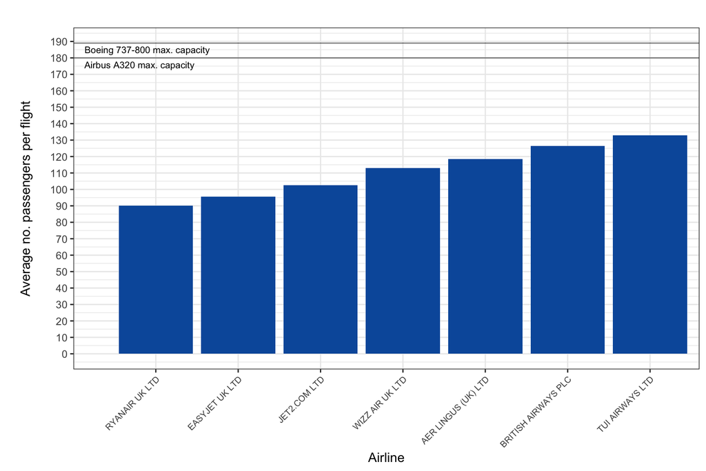

```r
# https://aircraft.airbus.com/en/aircraft/a320/a320ceo#:~:text=With%20a%20versatile%20cabin%20that,relax%20and%20enjoy%20the%20flight.
airbus.a320.max.capacity = 180
Boeing.737800.max.capacity = 189

p2 = dec21.allservices %>%
  dplyr::mutate(avg_passengers_per_flight=total_passengers_uplifted/no_flights) %>%
  dplyr::select(airline_name, avg_passengers_per_flight) %>%
  dplyr::filter(airline_name %in% c("AER LINGUS (UK) LTD", "BRITISH AIRWAYS PLC", "EASYJET UK LTD", "JET2.COM LTD", "RYANAIR UK LTD", "TUI AIRWAYS LTD", "WIZZ AIR UK LTD")) %>%

  ggplot(data=., aes(x=reorder(airline_name, avg_passengers_per_flight), y=avg_passengers_per_flight)) +
  theme_bw(base_size=12) +
  geom_col(fill=ba.cols[1]) +
  theme(axis.text.x = element_text(angle=45, size=8, hjust=1),
        plot.title = element_text(hjust = 0.5)
  ) +
  scale_x_discrete(labels = function(x) stringr::str_wrap(x, width = 40)) +
  ylab("\nAverage no. passengers per flight\n ") +
  xlab("Airline") +
  labs(title="") +
  geom_hline(yintercept=airbus.a320.max.capacity, alpha=0.5) +
  geom_text(aes(x=0, y=airbus.a320.max.capacity, label = "Airbus A320 max. capacity", vjust = 1.5, hjust=-0.1), fontface="plain", size=3, check_overlap=T) +
  geom_hline(yintercept=Boeing.737800.max.capacity, alpha=0.5) +
  geom_text(aes(x=0, y=Boeing.737800.max.capacity, label = "Boeing 737-800 max. capacity", vjust = 1.5, hjust=-0.09), fontface="plain", size=3, check_overlap=T) +
  scale_y_continuous(breaks = seq(0, 200, by=10))

p2
```

# Conclusions

- The main issue with this data, is that there is no per-flight breakdown, this is an average over all of the flights in the period
- We cannot discern from this data the distribution of un-used seats - i.e. how many planes fly empty vs. how many fly 50% empty etc.
- Some (hardly any) might be passengers <2, but the majority will be on laps anyway

```r
# avg.line = dec21.allservices$seat_km_unused_as_percent_of_avail %>% mean()
#
# p2 = dec21.allservices %>%
#
#   dplyr::select(airline_name, seat_km_used_as_percent_of_avail, seat_km_unused_as_percent_of_avail) %>%
#   dplyr::mutate(plot.order = seat_km_unused_as_percent_of_avail) %>%
#   tidyr::pivot_longer(., 2:3, names_to="seats", values_to="percent") %>%
#
#   ggplot(data=., aes(x=reorder(airline_name, plot.order), y=percent, fill=seats)) +
#   theme_bw(base_size=9) +
#   geom_bar(position="stack", stat="identity") +
#   theme(axis.text.x = element_text(angle=45, size=5, hjust=1),
#         plot.title = element_text(hjust = 0.5)
#   ) +
#   scale_x_discrete(labels = function(x) stringr::str_wrap(x, width = 40)) +
#   ylab("%") +
#   xlab("Airline") +
#   ylim(0,100) +
#   labs(title="\nBarplot to show the % unused seats per airline for 28 UK airlines.\n The horizontal line denotes the average seat km unused\n", fill="Seat km") +
#   geom_hline(yintercept=avg.line, colour=ba.cols[6])  +
#   scale_fill_manual(values=c(ba.cols[2], ba.cols[1]), labels = c("Not used", "Used"))
#
# p2
```